# PD, microbiome and host genetics

```r
wallenZD_data.mae
```

```
## A MultiAssayExperiment object of 6 listed
##  experiments with user-defined names and respective classes.
##  Containing an ExperimentList class object of length 6:
##  [1] genotypes_dosages.se: SummarizedExperiment with 519 rows and 696 columns
##  [2] genotypes_hardcalls.se: SummarizedExperiment with 519 rows and 696 columns
##  [3] metaphlan_RelAbund.se: SummarizedExperiment with 719 rows and 724 columns
##  [4] metaphlan_Counts.se: SummarizedExperiment with 720 rows and 724 columns
##  [5] humann_ko.se: SummarizedExperiment with 8528 rows and 724 columns
##  [6] humann_pathways.se: SummarizedExperiment with 511 rows and 724 columns
## Functionality:
##  experiments() - obtain the ExperimentList instance
##  colData() - the primary/phenotype DataFrame
##  sampleMap() - the sample coordination DataFrame
##  `$`, `[`, `[[` - extract colData columns, subset, or experiment
##  *Format() - convert into a long or wide DataFrame
##  assays() - convert ExperimentList to a SimpleList of matrices
##  exportClass() - save data to flat files
```

# 1 Assocation between PD markers and PD genetics

## 1.1 Cluster-wide biomarkers score (sum all)

Haydeh has manually curated a list of bacteria that go together into 6 different clusters elevated or decreased in PD. To see the genetic impact of PD associated variants on these bacteria without having to pay a high multiple testing price.

As a first simple approach we will sum all relative abundances together. Below is an example of the cluster names and bacteria associated with them.

```r
biomarkers_medrxiv.df <- readxl::read_xlsx("../Data/Biomarkers_Payami_medRxiv.xlsx")

datatable(biomarkers_medrxiv.df %>% select(-species_metaphlan))
```

|  | cluster_name | Species | PD association | Number of connections |
| --- | --- | --- | --- | --- |
| 1 | Opportunistic Pathogens | Actinomyces turicensis | Increased as cluster | 8 |
| 2 | Opportunistic Pathogens | Anaerococcus octavius | Increased as cluster | 4 |
| 3 | Opportunistic Pathogens | Anaerococcus vaginalis | Increased as cluster | 5 |
| 4 | Opportunistic Pathogens | Atopobium minutum | Increased as cluster | 8 |
| 5 | Opportunistic Pathogens | Corynebacterium amycolatum | Increased as cluster | 2 |
| 6 | Opportunistic Pathogens | Corynebacterium aurimucosum | Increased as cluster | 2 |
| 7 | Opportunistic Pathogens | Finegoldia magna | Increased as cluster | 7 |
| 8 | Opportunistic Pathogens | Gemella asaccharolytica | Increased as cluster | 2 |
| 9 | Opportunistic Pathogens | Peptoniphilus harei | Increased as cluster | 1 |
| 10 | Opportunistic Pathogens | Peptoniphilus lacrimalis | Increased as cluster | 3 |

[output cut: 49 more lines]

For each sample, we can calculate the sum of all bacteria within each cluster as one single value and use these as outcome variables. See below for the calculated values.

```r
cluster_sums.df <- left_join(biomarkers_medrxiv.df,
          as.data.frame(assay(wallenZD_data.mae, "metaphlan_RelAbund.se")/100) %>%
            rownames_to_column("species_metaphlan"),
          by = "species_metaphlan") %>%
  split.data.frame(f = .$cluster_name) %>%
  lapply(select, starts_with("D")) %>%
  lapply(colSums) %>%
  bind_cols(sample_name = names(.[[1]])) %>%
  relocate(sample_name)

cluster_sums.df %>%
  mutate_if(is.numeric, round, 3) %>%
datatable()
```

|  | sample_name | Bifidobacteria | E. coli-Klebsiella | Fiber Degraders | Lactobacilli | Opportunistic Pathogens | Strepto-Actino |
| --- | --- | --- | --- | --- | --- | --- | --- |
| 1 | DP310 | 0 | 0 | 0.112 | 0 | 0 | 0 |
| 2 | DP309 | 0 | 0 | 0.196 | 0 | 0 | 0 |
| 3 | DP308 | 0.095 | 0.005 | 0.015 | 0.001 | 0 | 0.003 |
| 4 | DP307 | 0.442 | 0.007 | 0.003 | 0.016 | 0 | 0 |
| 5 | DP305 | 0.491 | 0 | 0.147 | 0 | 0 | 0.002 |
| 6 | DP304 | 0.061 | 0.008 | 0.15 | 0 | 0 | 0.002 |
| 7 | DP303 | 0.12 | 0 | 0.133 | 0 | 0 | 0.013 |
| 8 | DP302 | 0 | 0 | 0.252 | 0 | 0 | 0 |
| 9 | DP301 | 0.003 | 0.039 | 0.312 | 0.005 | 0 | 0 |
| 10 | DP300 | 0.023 | 0.033 | 0.258 | 0 | 0 | 0.001 |

[output cut: 709 more lines]

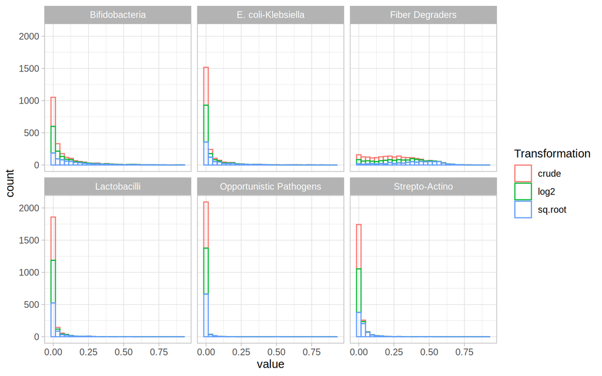

```r
cluster_sums.df %>%
  select(-sample_name) %>%
  reshape2::melt() %>%
  mutate(
    log2Transf = log2(value + 1),
    sq.root = sqrt(value)
    ) %>%
  reshape2::melt(
    variable.name = "Transformation"
    ) %>%
  mutate(
    Transformation = case_when(
      Transformation == "value" ~ 'crude',
      Transformation == "log2Transf" ~ 'log2',
      Transformation == "sq.root" ~ 'sq.root',
      TRUE ~ 'error'
      )
    ) %>%
  ggplot(aes(x = value, color = Transformation)) +
  geom_histogram(fill = "transparent") +
  facet_wrap(~variable) +
  theme_light()
```

## 1.2 Genotype dosages x PD microbiome clusters (lm)

Inclusion-exclusion criteria:

- Collection method should not be `swab`
- Variants of interest should be mapped to `HLA` and `SNCA` genes
- samples should be in common between genetics and microbiome

```r
samples_to_keep.df <- colData(wallenZD_data.mae[["metaphlan_RelAbund.se"]]) %>%
  as.data.frame() %>%
  filter(collection_method != "swab")

variants_to_keep_rowData.df <- as.data.frame(rowData(wallenZD_data.mae[["genotypes_dosages.se"]])[grepl("HLA|SNCA", rowData(wallenZD_data.mae[["genotypes_dosages.se"]])$GENE),])

per_sample_dosages.df <- t(assay(wallenZD_data.mae, "genotypes_dosages.se"))[,rownames(variants_to_keep_rowData.df)] %>%
  as.data.frame() %>%
  set_names(paste(variants_to_keep_rowData.df$CHROM, variants_to_keep_rowData.df$POS, sep = "_")) %>%
  rownames_to_column("sample_name")

data_alltogether.df <- inner_join(cluster_sums.df, per_sample_dosages.df, by = "sample_name") %>%
  inner_join(samples_to_keep.df, by = "sample_name")
```

Now perform the model as follows, which allows the interaction term and will spit out coefficients for both variables alone.

$$ClusterSum_i \sim Age + Seq.Depth + PD \times Variant_k$$

```r
clusters_vs_dosages.lm.list <- lapply(
  make.names(colnames(select(cluster_sums.df, -sample_name))) %>% set_names(colnames(select(cluster_sums.df, -sample_name))),
  function(cl) {
    sapply(
      colnames(select(per_sample_dosages.df, -sample_name)),
      function(gt) {
        f.la <- as.formula(
          paste(cl, "~ Age_at_collection + seqs_scaled + ", paste("Case_status", gt, sep = "*"))
        )
        return(
          lm(f.la, data = data_alltogether.df %>% rename_all(.funs =make.names))
        )
      },
      USE.NAMES = TRUE,
  simplify = FALSE
    )

  }
)

# number of tests to correct for as bonferroni: number of cluster + variants tested
n_tests <- length(clusters_vs_dosages.lm.list) + max(sapply(clusters_vs_dosages.lm.list, length))

lm_results_corrected_bonferoni.df <- lapply(clusters_vs_dosages.lm.list, function(x) purrr::reduce(lapply(x, broom::tidy), rbind.data.frame)) %>%
         bind_rows(.id = "cluster_name") %>%
  mutate(p.adj_bonferroni = p.value / n_tests)

lm_results_corrected_bonferoni_signif.df <- lm_results_corrected_bonferoni.df %>%
  filter(p.adj_bonferroni < 0.1, grepl("chr[0-9]", term)) %>%
  mutate_if(is.numeric, round, 3)
```

```r
lm_results_corrected_bonferoni_signif.df %>%
  arrange(desc(abs(estimate))) %>%
  datatable()
```

|  | cluster_name | term | estimate | std.error | statistic | p.value | p.adj_bonferroni |
| --- | --- | --- | --- | --- | --- | --- | --- |
| 1 | Fiber Degraders | Case_statusPD:chr4_89840793 | -0.051 | 0.017 | -3.002 | 0.003 | 0 |
| 2 | Fiber Degraders | Case_statusPD:chr4_89723303 | -0.047 | 0.023 | -2.009 | 0.045 | 0.002 |
| 3 | Fiber Degraders | Case_statusPD:chr4_89761323 | -0.045 | 0.025 | -1.839 | 0.066 | 0.003 |
| 4 | Fiber Degraders | Case_statusPD:chr6_32698883 | -0.044 | 0.023 | -1.906 | 0.057 | 0.002 |
| 5 | Fiber Degraders | Case_statusPD:chr4_89718364 | -0.042 | 0.023 | -1.823 | 0.069 | 0.003 |
| 6 | Fiber Degraders | chr4_89840793 | 0.039 | 0.014 | 2.735 | 0.006 | 0 |
| 7 | Fiber Degraders | Case_statusPD:chr6_32684419 | -0.035 | 0.024 | -1.476 | 0.14 | 0.006 |
| 8 | Fiber Degraders | chr4_89723303 | 0.033 | 0.02 | 1.61 | 0.108 | 0.004 |
| 9 | Fiber Degraders | Case_statusPD:chr4_89859751 | -0.032 | 0.024 | -1.291 | 0.197 | 0.008 |
| 10 | Fiber Degraders | chr4_89761323 | 0.03 | 0.022 | 1.381 | 0.168 | 0.007 |

[output cut: 218 more lines]

This variant, `chr4:89840793`, is particularly interesting because Fiber degraders are negatively associated in case of an interaction between that and PD, but they are increased in case of carrying more alternative alleles. The distribution is:

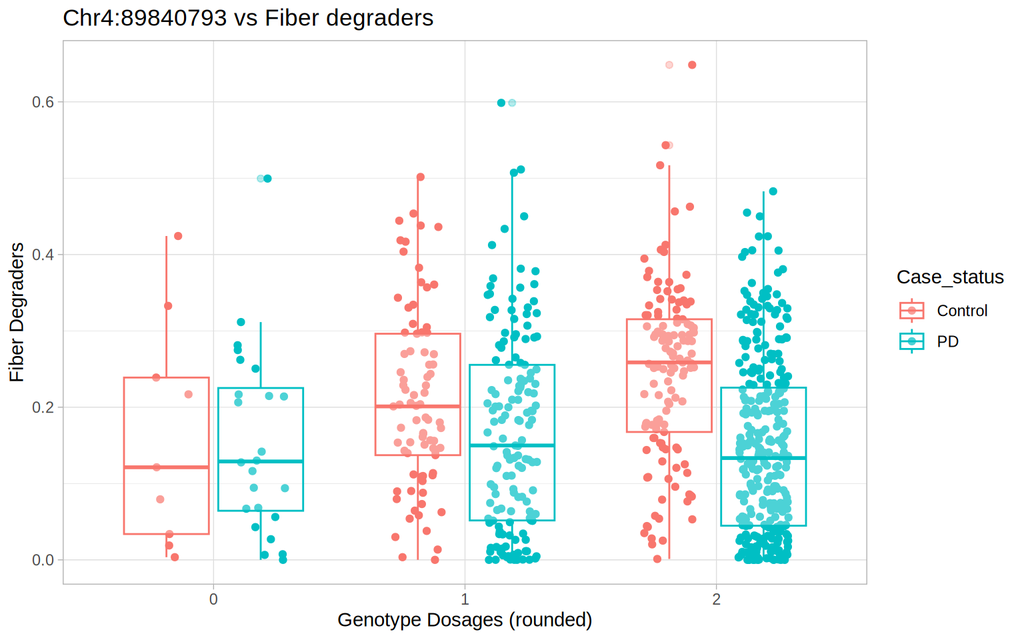

```r
ggplot(data_alltogether.df, aes(x = as.factor(round(chr4_89840793, 0)), y = `Fiber Degraders`, color = Case_status)) +
  geom_point(position = position_jitterdodge(jitter.width = 0.2)) +
  geom_boxplot(alpha = 0.3) +
  theme_light() +
  labs(
    x = "Genotype Dosages (rounded)",
    title = "Chr4:89840793 vs Fiber degraders"
  )
```

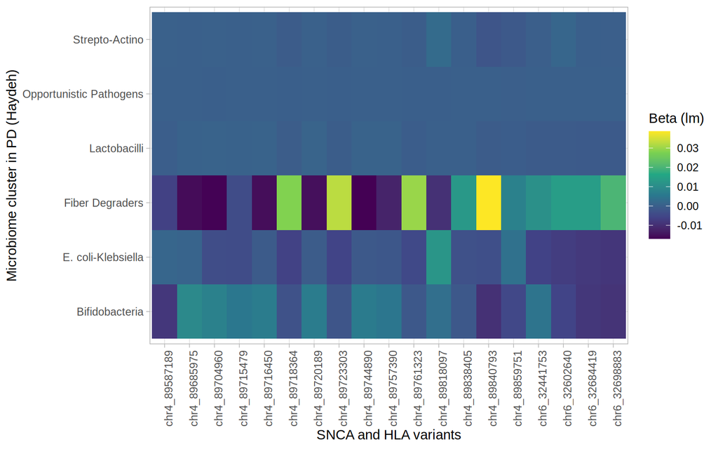

```r
lm_results_corrected_bonferoni.df %>%
  filter(grepl("^chr", term)) %>%
  ggplot(aes(x = term, y = cluster_name, fill = estimate)) +
  geom_tile() +
  scale_fill_viridis_c() +
  theme_light() +
  theme(axis.text.x = element_text(angle = 90)) +
  labs(
    x = "SNCA and HLA variants",
    y = "Microbiome cluster in PD (Haydeh)",
    fill = "Beta (lm)"
  )
```

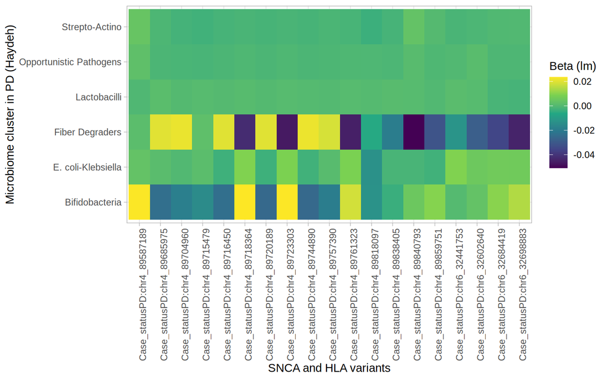

```r
lm_results_corrected_bonferoni.df %>%
  filter(grepl("PD:chr", term)) %>%
  ggplot(aes(x = term, y = cluster_name, fill = estimate)) +
  geom_tile() +
  scale_fill_viridis_c() +
  theme_light() +
  theme(axis.text.x = element_text(angle = 90)) +
  labs(
    x = "SNCA and HLA variants",
    y = "Microbiome cluster in PD (Haydeh)",
    fill = "Beta (lm)"
  )
```

Modeling assumptions are far from met, but we find a few associations with variants alone and variants in interaction with these bacterial clusters.

Questions are the following:

- Bacteria associated with variants alone
- Bacteria associated with a variant in case of PD but not in case of controls

# 2 BugSigDbR package to compare pre-published bugs